# Item Response Theory Models

## Hierarchical IRT Models

We can also estimate hierarchical IRT models which allow the mean of each alignment estimate to be a function of country level predictors.

$$\begin{align}
\text{Pr}(y_{ij} = 1) &= \text{logit}^{-1}(\beta_j\theta_i - \alpha_j) \\
\theta_i &\sim \mathcal{N}(\mathbf{x}_i\boldsymbol{\gamma}, \sigma^2)
\end{align}$$

where $boldsymbol{\gamma}$ is a vector of regression coefficients that controls the influence of the hierarchical predictors on the mean of the latent alignment for each country. Annoyingly, `MCMCpack` refers to the hierarchical predictor coefficients as $\boldsymbol{\beta}$, but I’ve used $\boldsymbol{\gamma}$ above as the convention in the IRT literature is that $\boldsymbol{\beta}$s are discrimination parameters. This model is also known as the multiple indicators, multiple causes (MIMIC) model as we observe multiple indicators which multiple predictors affect through the latent quantity. Let’s extend our UN voting IRT model by adding in a measure of polyarchy from V-Dem (Coppedge et al. 2017) and trade as a percentage of GDP from the World Bank (World Bank 2018).

```r
library(WDI)
library(vdem)

# download trade as a percent of GNI data
WB <- WDI(country = 'all',
          indicator = c('NE.TRD.GNFS.ZS'), start = '2015', end = '2015') %>%
  select(ccode = country, trade = NE.TRD.GNFS.ZS)

# read in polyarchy from VDEM
vdem <- extract_vdem(name_pattern = 'v2x_polyarchy',
                     include_sd = T, include_uncertainty = F) %>%
  filter(year == 2015) %>%
  select(ccode = vdem_country_name, polyarchy = v2x_polyarchy)

# join hierarchical predictors and drop missing values
votes_hier <- votes %>% left_join(vdem) %>% left_join(WB) %>%
  filter(!is.na(trade), !is.na(polyarchy))
```

```r
# recode vote values and convert to matrix
data_mat_hier <- votes_hier %>%
  select(-ccode, -trade, -polyarchy) %>%
  apply(2, function(x) ifelse(ifelse(x %in% 2:3, 0, x) >= 8, NA,
                              ifelse(x %in% 2:3, 0, x)))

# add rownames to votes matrix for presentation
rownames(data_mat_hier) <- votes_hier$ccode
```

The last step we need to do is extract our hierarchical predictors into a separate dataframe. The data are on very different scales because polyarchy is a normalized variable from its own measurement model, and some countries have trade valued higher than their total GDP.

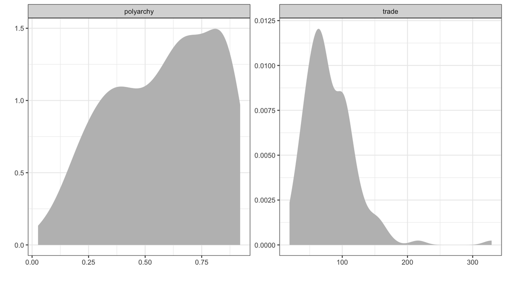

```r
# plot densities of hierarchical predictors
votes_hier %>% select(polyarchy, trade) %>%
  reshape2::melt() %>%
  ggplot(aes(x = value)) +
  geom_density(fill = 'grey', color = NA) +
  facet_wrap(~ variable, scales = 'free') +
  labs(x = '', y = '') +
  theme_bw()
```

To speed up the sampler and get meaningful results, we need to standardize both variables using the `scale()` function.

```r
# extract hierarchical predictors
xjdata <- votes_hier %>% select(trade:polyarchy) %>%
  mutate_all(function(x) as.numeric(scale(x)))
```

Once we’ve done that, we can estimate our hierarchical IRT model. Note that the information contained in the hierarchical predictors means that we no longer need to constrain the latent alignments of two countries to identify our model!

```r
# fit IRT model
irt_hier <- MCMCirtHier1d(datamatrix = data_mat_hier, Xjdata = xjdata)
```